# Project - 2 Healthcare PGP

```python
dataset3=dataset.drop(['Pregnancies','BloodPressure','DiabetesPedigreeFunction', 'Age','SkinThickness','Insulin','BMI'],axis=1)
dataset3
```

|  | Glucose | Outcome |
| --- | --- | --- |
| 0 | 148.0 | 1 |
| 1 | 85.0 | 0 |
| 2 | 183.0 | 1 |
| 3 | 89.0 | 0 |
| 4 | 137.0 | 1 |
| ... | ... | ... |
| 763 | 101.0 | 0 |
| 764 | 122.0 | 0 |
| 765 | 121.0 | 0 |
| 766 | 126.0 | 1 |
| 767 | 93.0 | 0 |

768 rows × 2 columns

```
          Glucose   Outcome
Glucose  1.000000  0.492908
Outcome  0.492908  1.000000
```

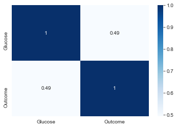

```python
g = sns.heatmap(dataset3.corr(),cmap="Blues",annot=True)
print(dataset3.corr())
```

## Project Task: Week 3

**Data Modeling:**

1. Devise strategies for model building. It is important to decide the right validation framework. Express your thought process.
2. Apply an appropriate classification algorithm to build a model. Compare various models with the results from KNN algorithm.
3. Create a classification report by analyzing sensitivity, specificity, AUC (ROC curve), etc. Please be descriptive to explain what values of these parameter you have used.

```python
# Data Modeling
X=dataset.iloc[:,:-1].values
y=dataset.iloc[:,-1].values
```

```python
#Train test split
from sklearn.model_selection import train_test_split
```

```python
X_train, X_test, y_train, y_test = train_test_split(X, y, test_size=0.2, random_state=10)
```

```python
#Create model
#Applying K-NN
from sklearn.neighbors import KNeighborsClassifier
model1 = KNeighborsClassifier(n_neighbors=7,
                             metric='minkowski',
                             p = 2)
model1.fit(X_train,y_train)
```

```
KNeighborsClassifier(n_neighbors=7)
```

```python
print(model1.score(X_train,y_train))
print(model1.score(X_test,y_test))
```

```
0.8078175895765473
0.7142857142857143
```

```python
from sklearn.metrics import confusion_matrix
cm = confusion_matrix(y,model1.predict(X))
cm
```

```
array([[432,  68],
       [ 94, 174]], dtype=int64)
```

```python
from sklearn.metrics import classification_report
print(classification_report(y,model1.predict(X)))
```

```
              precision    recall  f1-score   support

           0       0.82      0.86      0.84       500
           1       0.72      0.65      0.68       268

    accuracy                           0.79       768
   macro avg       0.77      0.76      0.76       768
weighted avg       0.79      0.79      0.79       768
```

```python
from sklearn import metrics

print("Accuracy = {0:.3f}".format(metrics.accuracy_score(y_test,model1.predict(X_test))))
```

```
Accuracy = 0.714
```

```
AUC: 0.847
```

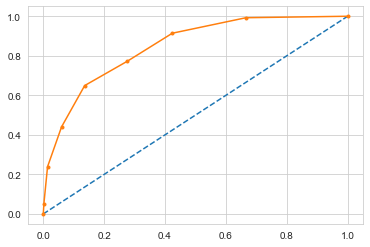

```python
#Preparing ROC Curve (Receiver Operating Characteristics Curve)
from sklearn.metrics import roc_curve
from sklearn.metrics import roc_auc_score

# predict probabilities
probs = model1.predict_proba(X)
# keep probabilities for the positive outcome only
probs = probs[:, 1]
# calculate AUC
auc = roc_auc_score(y, probs)
print('AUC: %.3f' % auc)
# calculate roc curve
fpr, tpr, thresholds = roc_curve(y, probs)
# plot no skill
plt.plot([0, 1], [0, 1], linestyle='--')
# plot the roc curve for the model
plt.plot(fpr, tpr, marker='.')
```

```
f1=0.682 auc=0.754 ap=0.715
```

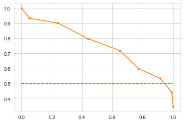

```python
#Precision Recall Curve for KNN

from sklearn.metrics import precision_recall_curve
from sklearn.metrics import f1_score
from sklearn.metrics import auc
from sklearn.metrics import average_precision_score
# predict probabilities
probs = model1.predict_proba(X)
# keep probabilities for the positive outcome only
probs = probs[:, 1]
# predict class values
yhat = model1.predict(X)
# calculate precision-recall curve
precision, recall, thresholds = precision_recall_curve(y, probs)
# calculate F1 score
f1 = f1_score(y, yhat)
# calculate precision-recall AUC
auc = auc(recall, precision)
# calculate average precision score
ap = average_precision_score(y, probs)
print('f1=%.3f auc=%.3f ap=%.3f' % (f1, auc, ap))
# plot no skill
plt.plot([0, 1], [0.5, 0.5], linestyle='--')
# plot the precision-recall curve for the model
plt.plot(recall, precision, marker='.')
```

```python
#Create model
#Applying LogisticRegression
from sklearn.linear_model import LogisticRegression
model2 = LogisticRegression()
model2.fit(X_train,y_train)
```

```
LogisticRegression()
```

```python
print(model2.score(X_train,y_train))
print(model2.score(X_test,y_test))
```

```
0.7703583061889251
0.7272727272727273
```

```python
from sklearn.metrics import confusion_matrix
cm = confusion_matrix(y,model2.predict(X))
cm
```

```
array([[441,  59],
       [124, 144]], dtype=int64)
```

```python
from sklearn.metrics import classification_report
print(classification_report(y,model2.predict(X)))
```

```
              precision    recall  f1-score   support

           0       0.78      0.88      0.83       500
           1       0.71      0.54      0.61       268

    accuracy                           0.76       768
   macro avg       0.74      0.71      0.72       768
weighted avg       0.76      0.76      0.75       768
```

```python
from sklearn import metrics

print("Accuracy = {0:.3f}".format(metrics.accuracy_score(y_test,model2.predict(X_test))))
```

```
Accuracy = 0.727
```

```
AUC: 0.842
```

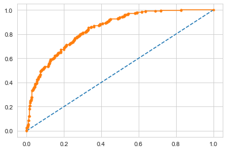

```python
#Preparing ROC Curve (Receiver Operating Characteristics Curve)
from sklearn.metrics import roc_curve
from sklearn.metrics import roc_auc_score

# predict probabilities
probs = model2.predict_proba(X)
# keep probabilities for the positive outcome only
probs = probs[:, 1]
# calculate AUC
auc = roc_auc_score(y, probs)
print('AUC: %.3f' % auc)
# calculate roc curve
fpr, tpr, thresholds = roc_curve(y, probs)
# plot no skill
plt.plot([0, 1], [0, 1], linestyle='--')
# plot the roc curve for the model
plt.plot(fpr, tpr, marker='.')
```

```
f1=0.611 auc=0.723 ap=0.724
```

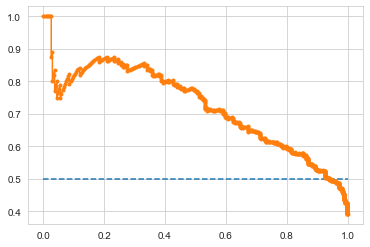

```python
#Precision Recall Curve for Logestic Regreesion

from sklearn.metrics import precision_recall_curve
from sklearn.metrics import f1_score
from sklearn.metrics import auc
from sklearn.metrics import average_precision_score
# predict probabilities
probs = model2.predict_proba(X)
# keep probabilities for the positive outcome only
probs = probs[:, 1]
# predict class values
yhat = model2.predict(X)
# calculate precision-recall curve
precision, recall, thresholds = precision_recall_curve(y, probs)
# calculate F1 score
f1 = f1_score(y, yhat)
# calculate precision-recall AUC
auc = auc(recall, precision)
# calculate average precision score
ap = average_precision_score(y, probs)
print('f1=%.3f auc=%.3f ap=%.3f' % (f1, auc, ap))
# plot no skill
plt.plot([0, 1], [0.5, 0.5], linestyle='--')
# plot the precision-recall curve for the model
plt.plot(recall, precision, marker='.')
```

```python
#Applying Decission Tree Classifier
from sklearn.tree import DecisionTreeClassifier
model3 = DecisionTreeClassifier(max_depth=5)
model3.fit(X_train,y_train)
```

```
DecisionTreeClassifier(max_depth=5)
```

```python
print(model3.score(X_train,y_train))
print(model3.score(X_test,y_test))
```

```
0.8273615635179153
0.7532467532467533
```

```python
from sklearn.metrics import confusion_matrix
cm = confusion_matrix(y,model3.predict(X))
cm
```

```
array([[432,  68],
       [ 76, 192]], dtype=int64)
```

```python
from sklearn.metrics import classification_report
print(classification_report(y,model3.predict(X)))
```

```
              precision    recall  f1-score   support

           0       0.85      0.86      0.86       500
           1       0.74      0.72      0.73       268

    accuracy                           0.81       768
   macro avg       0.79      0.79      0.79       768
weighted avg       0.81      0.81      0.81       768
```

```python
from sklearn import metrics

print("Accuracy = {0:.3f}".format(metrics.accuracy_score(y_test,model3.predict(X_test))))
```

```
Accuracy = 0.753
```

```
AUC: 0.882
```

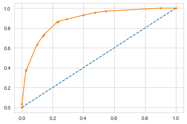

```python
#Preparing ROC Curve (Receiver Operating Characteristics Curve)
from sklearn.metrics import roc_curve
from sklearn.metrics import roc_auc_score

# predict probabilities
probs = model3.predict_proba(X)
# keep probabilities for the positive outcome only
probs = probs[:, 1]
# calculate AUC
auc = roc_auc_score(y, probs)
print('AUC: %.3f' % auc)
# calculate roc curve
fpr, tpr, thresholds = roc_curve(y, probs)
# plot no skill
plt.plot([0, 1], [0, 1], linestyle='--')
# plot the roc curve for the model
plt.plot(fpr, tpr, marker='.')
```

```
f1=0.727 auc=0.809 ap=0.768
```

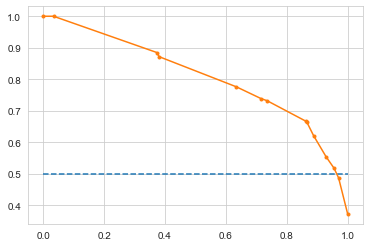

```python
#Precision Recall Curve for Decission Tree Classifier

from sklearn.metrics import precision_recall_curve
from sklearn.metrics import f1_score
from sklearn.metrics import auc
from sklearn.metrics import average_precision_score
# predict probabilities
probs = model3.predict_proba(X)
# keep probabilities for the positive outcome only
probs = probs[:, 1]
# predict class values
yhat = model3.predict(X)
# calculate precision-recall curve
precision, recall, thresholds = precision_recall_curve(y, probs)
# calculate F1 score
f1 = f1_score(y, yhat)
# calculate precision-recall AUC
auc = auc(recall, precision)
# calculate average precision score
ap = average_precision_score(y, probs)
print('f1=%.3f auc=%.3f ap=%.3f' % (f1, auc, ap))
# plot no skill
plt.plot([0, 1], [0.5, 0.5], linestyle='--')
# plot the precision-recall curve for the model
plt.plot(recall, precision, marker='.')
```

```python
#Applying Random Forest
from sklearn.ensemble import RandomForestClassifier
model4 = RandomForestClassifier(n_estimators=11)
model4.fit(X_train,y_train)
```

```
RandomForestClassifier(n_estimators=11)
```

```python
print(model4.score(X_train,y_train))
print(model4.score(X_test,y_test))
```

```
0.993485342019544
0.7207792207792207
```

```python
from sklearn.metrics import confusion_matrix
cm = confusion_matrix(y,model4.predict(X))
cm
```

```
array([[486,  14],
       [ 33, 235]], dtype=int64)
```

```python
from sklearn.metrics import classification_report
print(classification_report(y,model4.predict(X)))
```

```
              precision    recall  f1-score   support

           0       0.94      0.97      0.95       500
           1       0.94      0.88      0.91       268

    accuracy                           0.94       768
   macro avg       0.94      0.92      0.93       768
weighted avg       0.94      0.94      0.94       768
```

```python
from sklearn import metrics

print("Accuracy = {0:.3f}".format(metrics.accuracy_score(y_test,model4.predict(X_test))))
```

```
Accuracy = 0.721
```

```
AUC: 0.978
```

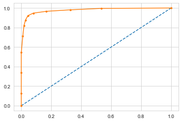

```python
#Preparing ROC Curve (Receiver Operating Characteristics Curve)
from sklearn.metrics import roc_curve
from sklearn.metrics import roc_auc_score

# predict probabilities
probs = model4.predict_proba(X)
# keep probabilities for the positive outcome only
probs = probs[:, 1]
# calculate AUC
auc = roc_auc_score(y, probs)
print('AUC: %.3f' % auc)
# calculate roc curve
fpr, tpr, thresholds = roc_curve(y, probs)
# plot no skill
plt.plot([0, 1], [0, 1], linestyle='--')
# plot the roc curve for the model
plt.plot(fpr, tpr, marker='.')
```

```
f1=0.909 auc=0.969 ap=0.961
```

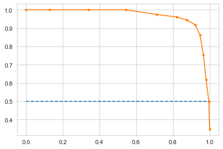

```python
#Precision Recall Curve for Random Forest

from sklearn.metrics import precision_recall_curve
from sklearn.metrics import f1_score
from sklearn.metrics import auc
from sklearn.metrics import average_precision_score
# predict probabilities
probs = model4.predict_proba(X)
# keep probabilities for the positive outcome only
probs = probs[:, 1]
# predict class values
yhat = model4.predict(X)
# calculate precision-recall curve
precision, recall, thresholds = precision_recall_curve(y, probs)
# calculate F1 score
f1 = f1_score(y, yhat)
# calculate precision-recall AUC
auc = auc(recall, precision)
# calculate average precision score
ap = average_precision_score(y, probs)
print('f1=%.3f auc=%.3f ap=%.3f' % (f1, auc, ap))
# plot no skill
plt.plot([0, 1], [0.5, 0.5], linestyle='--')
# plot the precision-recall curve for the model
plt.plot(recall, precision, marker='.')
```

```python
from sklearn.svm import SVC
from sklearn.metrics import accuracy_score
LogReg=LogisticRegression(random_state=24)
tree= DecisionTreeClassifier(random_state=24) # using the random state for reproducibility
forest= RandomForestClassifier(random_state=24)
knn= KNeighborsClassifier()
svm=SVC()
# now, create a list with the objects
models= [LogReg,tree, forest, knn, svm]

for model in models:
    model.fit(X_train, y_train) # fit the model
    y_pred= model.predict(X_test) # then predict on the test set
    accuracy= accuracy_score(y_test, y_pred) # this gives us how often the algorithm predicted correctly
    clf_report= classification_report(y_test, y_pred) # with the report, we have a bigger picture, with precision and recall for each class
    print(f"The accuracy of model {type(model).__name__} is {accuracy:.2f}")
    print(clf_report)
    print("\n")
```

```
The accuracy of model LogisticRegression is 0.73
              precision    recall  f1-score   support

           0       0.73      0.88      0.80        95
           1       0.72      0.47      0.57        59

    accuracy                           0.73       154
   macro avg       0.72      0.68      0.69       154
weighted avg       0.73      0.73      0.71       154



The accuracy of model DecisionTreeClassifier is 0.74
              precision    recall  f1-score   support

           0       0.78      0.81      0.79        95
           1       0.67      0.63      0.65        59

    accuracy                           0.74       154
   macro avg       0.73      0.72      0.72       154
weighted avg       0.74      0.74      0.74       154



The accuracy of model RandomForestClassifier is 0.73
              precision    recall  f1-score   support

           0       0.74      0.88      0.80        95
           1       0.72      0.49      0.59        59

    accuracy                           0.73       154
   macro avg       0.73      0.69      0.69       154
weighted avg       0.73      0.73      0.72       154



The accuracy of model KNeighborsClassifier is 0.71
              precision    recall  f1-score   support

           0       0.74      0.82      0.78        95
           1       0.65      0.54      0.59        59

    accuracy                           0.71       154
   macro avg       0.70      0.68      0.69       154
weighted avg       0.71      0.71      0.71       154



The accuracy of model SVC is 0.69
              precision    recall  f1-score   support

           0       0.69      0.92      0.79        95
           1       0.71      0.34      0.46        59

    accuracy                           0.69       154
   macro avg       0.70      0.63      0.62       154
weighted avg       0.70      0.69      0.66       154
```

## Project Task: Week 4

**Data Reporting:**

1. Create a dashboard in tableau by choosing appropriate chart types and metrics useful for the business. The dashboard must entail the following:

a. Pie chart to describe the diabetic or non-diabetic population

b. Scatter charts between relevant variables to analyze the relationships

c. Histogram or frequency charts to analyze the distribution of the data

d. Heatmap of correlation analysis among the relevant variables

e. Create bins of these age values: 20-25, 25-30, 30-35, etc. Analyze different variables for these age brackets using a bubble chart.

```python
from PIL import Image as PILImage
import base64, io, IPython
def image_import(image_path):
    image = PILImage.open(image_path)
    output = io.BytesIO()
    image.save(output, format='PNG')
    encoded_string = base64.b64encode(output.getvalue()).decode()
    html = '<img src="data:…"/>'.format(encoded_string)
    return IPython.display.HTML(html)
```

# Screenshot 1 - Task 1(a) - Pie chart to describe the diabetic or non-diabetic population

[figure not shown]

```python
image_import('Pie Chart.png')
```

# Screenshot 2 - Task 1(b) - Scatter charts between relevant variables to analyze the relationships

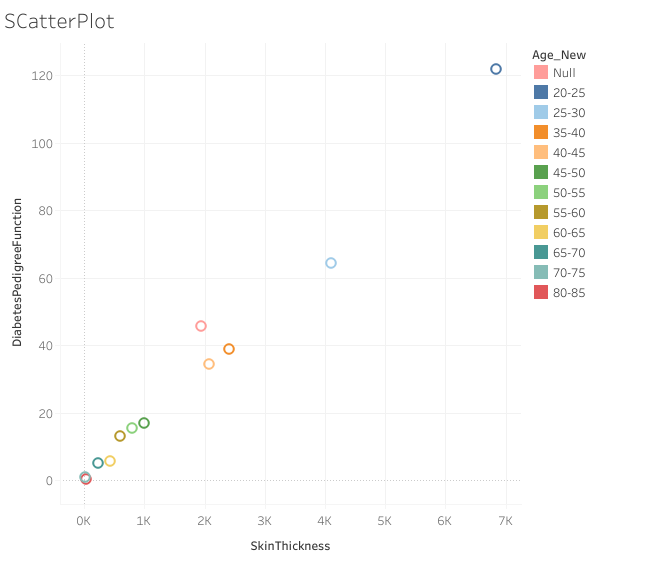

```python
image_import("SCatterPlot.png")
```

# Screenshot 3 - Task 1(c) - Histogram or frequency charts to analyze the distribution of the data

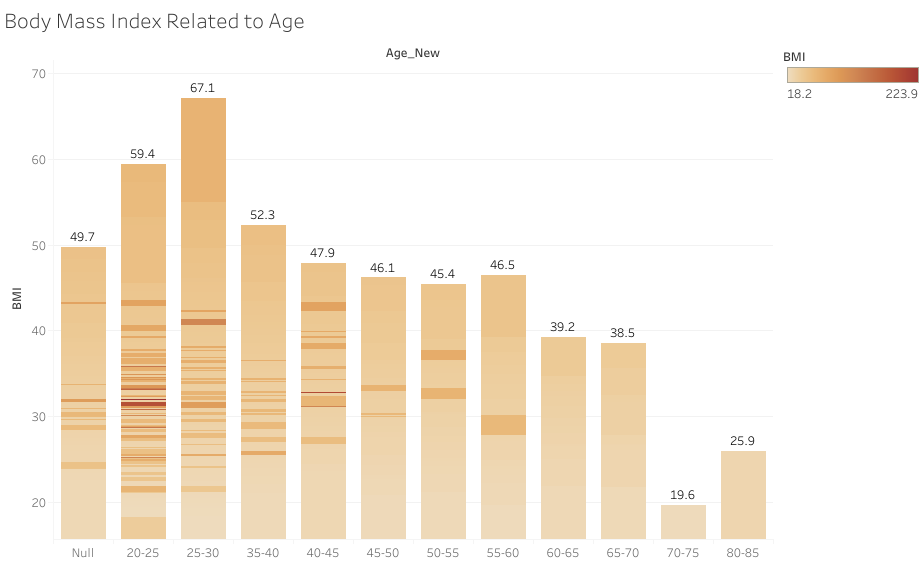

```python
image_import("Body Mass Index Related to Age.png")
```